### Data science fundamentals:

##### Wrangle data (Jul 30, 19)

```
## 'data.frame':    1112 obs. of  23 variables:
##  $ KEY              : Factor w/ 1527 levels "133370A","133370B",..: 28 43 44 53 55 70 84 90 100 107 ...
##  $ GENDER           : Factor w/ 2 levels "M","F": 1 1 1 1 1 1 1 1 1 1 ...
##  $ SPAGE            : int  29 28 27 24 30 26 31 32 34 32 ...
##  $ AGEGROUP         : Factor w/ 3 levels "20-39","40-59",..: 1 1 1 1 1 1 1 1 1 1 ...
##  $ HSQ_1            : Factor w/ 5 levels "Excellent","Very Good",..: 2 2 2 1 1 3 1 2 1 3 ...
##  $ UCREATININE      : int  105 53 314 105 163 150 46 36 177 156 ...
##  $ UALBUMIN         : num  0.707 1 8 4 3 2 2 0.707 4 3 ...
##  $ UACR             : num  0.00673 2 3 4 2 ...
##  $ MERCURYU         : num  0.37 0.106 0.487 2.205 0.979 ...
##  $ DX_DBTS          : Factor w/ 3 levels "DIAB","DIAB NO_DX",..: 3 3 3 3 3 3 3 3 3 3 ...
##  $ A1C              : num  5 5.2 4.8 5.1 4.3 5.2 4.8 5.2 4.8 5.2 ...
##  $ CADMIUM          : num  0.2412 0.1732 0.0644 0.0929 0.1202 ...
##  $ LEAD             : num  1.454 1.019 0.863 1.243 0.612 ...
##  $ MERCURYTOTALBLOOD: num  2.34 2.57 1.32 14.66 2.13 ...
##  $ HDL              : int  42 51 42 61 52 50 57 56 42 44 ...
##  $ CHOLESTEROLTOTAL : int  184 157 145 206 120 155 156 235 156 120 ...
##  $ GLUCOSESI        : num  4.61 4.77 5.16 5 5.11 ...
##  $ CREATININESI     : num  74.3 73 80 84.9 66 ...
##  $ CREATININE       : num  0.84 0.83 0.91 0.96 0.75 0.99 0.9 0.84 0.93 1.09 ...
##  $ TRIGLYCERIDE     : int  156 43 108 65 51 29 31 220 82 35 ...
##  $ GLUCOSE          : int  83 86 93 90 92 85 72 87 96 92 ...
##  $ COTININE         : num  31.5918 0.0635 0.035 0.0514 0.035 ...
##  $ LDLESTIMATE      : int  111 97 81 132 58 99 93 135 98 69 ...
##  - attr(*, "na.action")= 'omit' Named int  2 15 16 24 26 28 33 34 35 39 ...
##   ..- attr(*, "names")= chr  "2" "15" "16" "24" ...
```

#### Reading files and parsing

If you want to download the full HANES dataset, use the `download.file()` function

```r
download.file(url = URL, destfile = "HANES.original.csv")
```

Comma Seperated Values (CSV) are the most common types of files. We can read a `.csv` file directly into a tibble format through the function `readr::read_csv()` which is a modified version of the base function `read.csv()`.

```r
  # Read the HANES orginal csv file
  URL_text_1 <- "https://raw.githubusercontent.com/kannan-kasthuri/kannan-kasthuri.github.io"
  URL_text_2 <- "/master/Datasets/HANES/HANES.original.csv"
  # Paste it to constitute a single URL
  URL <- paste(URL_text_1, URL_text_2, sep="")
  HANES_original <- read.csv(text = getURL(URL), stringsAsFactors = FALSE)
```

When the data contains character vectors, parsing of these vectors can be done through the parsing function:

```r
# Parse a logical vector
  str(parse_logical(c("TRUE", "FALSE", "NA")))
```

```
##  logi [1:3] TRUE FALSE NA
```

```r
# Parse whether we have non-integer numbers
  # DMQ_5 (In what country was SP born?) is a character (factor) variable
  str(parse_integer(HANES_original$DMQ_5))
```

```
##  int [1:1527] 10 10 10 10 10 10 66 10 10 10 ...
##  - attr(*, "problems")=Classes 'tbl_df', 'tbl' and 'data.frame': 8 obs. of  4 variables:
##   ..$ row     : int [1:8] 176 383 624 696 937 1040 1331 1486
##   ..$ col     : int [1:8] NA NA NA NA NA NA NA NA
##   ..$ expected: chr [1:8] "an integer" "an integer" "an integer" "an integer" ...
##   ..$ actual  : chr [1:8] "R" "R" "DN" "R" ...
```

```r
# Display parse_* findings/problems as a table
problems(parse_integer(HANES_original$DMQ_5))
```

```
## # A tibble: 8 x 4
##     row   col expected   actual
##   <int> <int> <chr>      <chr>
## 1   176    NA an integer R
## 2   383    NA an integer R
## 3   624    NA an integer DN
## 4   696    NA an integer R
## 5   937    NA an integer DN
## 6  1040    NA an integer R
## 7  1331    NA an integer DN
## 8  1486    NA an integer DN
```

```r
# Parse a date vector
  str(parse_date(c("2010-01-01", "1979-10-14")))
```

```
##  Date[1:2], format: "2010-01-01" "1979-10-14"
```

```r
# Regroup several cases under new categoies (from the ::forcats package)
  fct_x <- as.character(3:10)
  fct_x
```

```
## [1] "3"  "4"  "5"  "6"  "7"  "8"  "9"  "10"
```

```r
  fct_x <- factor(fct_x)
  fct_x <- fct_collapse(fct_x, '7 or more' = as.character(7:10))
  fct_x
```

```
## [1] 3         4         5         6         7 or more 7 or more 7 or more
## [8] 7 or more
## Levels: 7 or more 3 4 5 6
```

Parsing different **number formats** are important as it comes in various styles:

1. People write numbers differently in different parts of the world. For example, some countries use `.` in between the integer and fractional parts of a real number, while others use `,`.
2. Numbers are often surrounded by other characters that provide some context, like “$1000” or “10%”.
3. Numbers often contain “grouping” characters to make them easier to read, like “1,000,000”, and these grouping characters vary around the world.

The first problem is solved by the argument `locale` in `parse_double()` function, the second using `parse_number()` function and the third by combination of `locale` and `parse_number()`.

```r
  # Parse a number of the format 1,23 where `,` indicates the decimal mark
  parse_double("1,63", locale = locale(decimal_mark = ","))
  # Just parse the number for $120 and 60%
  parse_number("$120")
  parse_number("60%")
  # Parse the grouping as used in Europe
  parse_number("123.834.297", locale = locale(grouping_mark = "."))
  # or as used in Switzerland
  parse_number("123'834'297", locale = locale(grouping_mark = "'"))
  # Parse grouping and decimal marks as used in colombia and other latin countries
  parse_number("123.834,297", locale = locale(grouping_mark = ".", decimal_mark = ","))
```

```
## [1] 1.63
```

```
## [1] 120
```

```
## [1] 60
```

```
## [1] 123834297
```

```
## [1] 123834297
```

```
## [1] 123834.3
```

Parsing date and time is very important in health related data sets. For example, the MIMIC3 data has tons of data sets with time information.

There are three main functions for parsing dates and times.

- `parse_datetime()` expects an ISO8601 date-time. ISO8601 is an international standard in which the components of a date are organised from biggest to smallest: year, month, day, hour, minute, second.
- `parse_date()` expects a four digit year, a - or /, the month, a - or /, then the day
- `parse_time()` expects the hour, :, minutes, optionally : and seconds, and an optional am/pm specifier

```r
  # Parse datetime
  parse_datetime("2010-10-01T2010")
```

```
## [1] "2010-10-01 20:10:00 UTC"
```

```r
  # Parse date
  parse_date("2010-10-01")
```

```
## [1] "2010-10-01"
```

```r
  # Parse time
  library(hms)
  parse_time("01:10 am")
```

```
## 01:10:00
```

If the deafults doesn’t work, there are several options as follows:

- Year: %Y (4 digits), %y (2 digits); 00-69 -> 2000-2069, 70-99 -> 1970-1999.
- Month: %m (2 digits), %b (abbreviated name, like “Jan”), %B (full name, “January”).
- Day: %d (2 digits), %e (optional leading space).
- Time: %H 0-23 hour, %I 0-12, must be used with %p, %p AM/PM indicator, %M minutes, %S integer seconds, %OS real seconds, %Z Time zone (as name, e.g. America/Chicago).
- Non-digits: %. skips one non-digit character, %* skips any number of non-digits.

As an example: (all outputs are in the format yyyy-mm-dd)

```r
  # Parse date in month/day/year format
  parse_date("01/02/15", "%m/%d/%y")
  # Parse date in day/month/year format
  parse_date("01/02/2015", "%d/%m/%Y")
  # Parse date in year/month/date format
  parse_date("01/02/15", "%y/%m/%d")
  # We can even set the `locale` option to specify different built in languages for the date
  parse_date("1 janvier 2015", "%d %B %Y", locale = locale("fr"))
```

```
## [1] "2015-01-02"
```

```
## [1] "2015-02-01"
```

```
## [1] "2001-02-15"
```

```
## [1] "2015-01-01"
```

**Classwork/Homework**: Read section 11.4 and 11.5 (Parsing a file and Writing to a file sections ) in R for Data Science book.

#### Dealing with dates and times

Dealing with dates and times can be a very tough job. For example, consider the MIMIC3 admissions table which has several time variables.

**Note**: MIMIC3 says “dates were shifted into the future by a random offset for each individual patient in a consistent manner to preserve intervals, resulting in stays which occur sometime between the years 2100 and 2200.” so don’t freak out looking at the dates.

If we import the dataset without `stringsAsFactors = F` , the `parse_date()` function fails to process the factor

```r
  # Load the package RCurl
  library(RCurl)
  # Import the admissions data set in MIMIC3 from GitHub;
  URL_text_1 <- "https://raw.githubusercontent.com/kannan-kasthuri/kannan-kasthuri.github.io"
  URL_text_2 <- "/master/Datasets/MIMIC3/admissions.csv"
  URL <- paste(URL_text_1,URL_text_2, sep="")
  MIMIC3_ADM <- read.csv(text=getURL(URL), stringsAsFactors = FALSE)
  # Observe the structure
  str(MIMIC3_ADM)
  # Parse the admission time using `parse_date()` function
  head(parse_date(MIMIC3_ADM$admittime, "%Y-%m-%d"))
```

```
## 'data.frame':    5770 obs. of  19 variables:
##  $ row_id              : int  83 84 85 86 87 88 89 90 91 92 ...
##  $ subject_id          : int  82 83 84 84 85 85 86 87 88 89 ...
##  $ hadm_id             : int  110641 158569 120969 166401 116630 112077 190243 190659 123010 188646 ...
##  $ admittime           : chr  "2150-06-24" "2142-04-01" "2196-02-02" "2196-04-14" ...
##  $ dischtime           : chr  "2150-06-29 15:00:00" "2142-04-08 14:46:00" "2196-02-04 17:48:00" "2196-04-17 13:42:00" ...
##  $ deathtime           : chr  NA NA NA "2196-04-17 13:42:00" ...
##  $ admission_type      : chr  "NEWBORN" "URGENT" "ELECTIVE" "EMERGENCY" ...
##  $ admission_location  : chr  "PHYS REFERRAL/NORMAL DELI" "TRANSFER FROM HOSP/EXTRAM" "PHYS REFERRAL/NORMAL DELI" "EMERGENCY ROOM ADMIT" ...
##  $ discharge_location  : chr  "HOME" "HOME HEALTH CARE" "HOME" "DEAD/EXPIRED" ...
##  $ insurance           : chr  "Private" "Medicare" "Private" "Private" ...
##  $ language            : chr  NA NA NA NA ...
##  $ religion            : chr  "UNOBTAINABLE" "UNOBTAINABLE" "OTHER" "OTHER" ...
##  $ marital_status      : chr  NA "MARRIED" "MARRIED" "MARRIED" ...
##  $ ethnicity           : chr  "OTHER" "UNKNOWN/NOT SPECIFIED" "WHITE" "WHITE" ...
##  $ edregtime           : chr  NA NA NA "2196-04-13 22:23:00" ...
##  $ edouttime           : chr  NA NA NA "2196-04-14 04:31:00" ...
##  $ diagnosis           : chr  "NEWBORN" "CAROTID STENOSIS" "MEDIAL PARIETAL TUMOR/SDA" "GLIOBLASTOMA,NAUSEA" ...
##  $ hospital_expire_flag: int  0 0 0 1 0 0 0 0 0 0 ...
##  $ has_chartevents_data: int  1 1 0 1 1 1 1 1 1 1 ...
```

```
## [1] "2150-06-24" "2142-04-01" "2196-02-02" "2196-04-14" "2162-03-02"
## [6] "2167-07-25"
```

Another approach is to use the helpers provided by the library *`lubridate`*.

They automatically work out the format once we specify the order of the component.

To use them, we have to identify the order in which year, month, and day appear in our data, then arrange “y”, “m”, and “d” in the same order.

That gives the name of the lubridate function that will parse our date.

To use this, we need to load the lubridate library.

```r
  # Load the lubridate library
  library(lubridate)
  # Since admission time has the format year/month/time, we pass ymd
  MIMIC3_ADM$admittime <- ymd(MIMIC3_ADM$admittime)
  # View the format
  str(MIMIC3_ADM)
  # Print the first few dates
  head(MIMIC3_ADM$admittime)
```

```
## 'data.frame':    5770 obs. of  19 variables:
##  $ row_id              : int  83 84 85 86 87 88 89 90 91 92 ...
##  $ subject_id          : int  82 83 84 84 85 85 86 87 88 89 ...
##  $ hadm_id             : int  110641 158569 120969 166401 116630 112077 190243 190659 123010 188646 ...
##  $ admittime           : Date, format: "2150-06-24" "2142-04-01" ...
##  $ dischtime           : chr  "2150-06-29 15:00:00" "2142-04-08 14:46:00" "2196-02-04 17:48:00" "2196-04-17 13:42:00" ...
##  $ deathtime           : chr  NA NA NA "2196-04-17 13:42:00" ...
##  $ admission_type      : chr  "NEWBORN" "URGENT" "ELECTIVE" "EMERGENCY" ...
##  $ admission_location  : chr  "PHYS REFERRAL/NORMAL DELI" "TRANSFER FROM HOSP/EXTRAM" "PHYS REFERRAL/NORMAL DELI" "EMERGENCY ROOM ADMIT" ...
##  $ discharge_location  : chr  "HOME" "HOME HEALTH CARE" "HOME" "DEAD/EXPIRED" ...
##  $ insurance           : chr  "Private" "Medicare" "Private" "Private" ...
##  $ language            : chr  NA NA NA NA ...
##  $ religion            : chr  "UNOBTAINABLE" "UNOBTAINABLE" "OTHER" "OTHER" ...
##  $ marital_status      : chr  NA "MARRIED" "MARRIED" "MARRIED" ...
##  $ ethnicity           : chr  "OTHER" "UNKNOWN/NOT SPECIFIED" "WHITE" "WHITE" ...
##  $ edregtime           : chr  NA NA NA "2196-04-13 22:23:00" ...
##  $ edouttime           : chr  NA NA NA "2196-04-14 04:31:00" ...
##  $ diagnosis           : chr  "NEWBORN" "CAROTID STENOSIS" "MEDIAL PARIETAL TUMOR/SDA" "GLIOBLASTOMA,NAUSEA" ...
##  $ hospital_expire_flag: int  0 0 0 1 0 0 0 0 0 0 ...
##  $ has_chartevents_data: int  1 1 0 1 1 1 1 1 1 1 ...
```

```
## [1] "2150-06-24" "2142-04-01" "2196-02-02" "2196-04-14" "2162-03-02"
## [6] "2167-07-25"
```

We also see the discharge time has both date and time formats so we can use `parse_datetime()` function to convert from the factor format.

```r
  # Load the lubridate library
  library(lubridate)
  # Since discharge time has both date and time attributes we may parse using datetime function
  MIMIC3_ADM$dischtime <- parse_datetime(MIMIC3_ADM$dischtime)
  # View the format
  str(MIMIC3_ADM)
  # Print the first few dates and times
  head(MIMIC3_ADM$dischtime)
```

```
## 'data.frame':    5770 obs. of  19 variables:
##  $ row_id              : int  83 84 85 86 87 88 89 90 91 92 ...
##  $ subject_id          : int  82 83 84 84 85 85 86 87 88 89 ...
##  $ hadm_id             : int  110641 158569 120969 166401 116630 112077 190243 190659 123010 188646 ...
##  $ admittime           : Date, format: "2150-06-24" "2142-04-01" ...
##  $ dischtime           : POSIXct, format: "2150-06-29 15:00:00" "2142-04-08 14:46:00" ...
##  $ deathtime           : chr  NA NA NA "2196-04-17 13:42:00" ...
##  $ admission_type      : chr  "NEWBORN" "URGENT" "ELECTIVE" "EMERGENCY" ...
##  $ admission_location  : chr  "PHYS REFERRAL/NORMAL DELI" "TRANSFER FROM HOSP/EXTRAM" "PHYS REFERRAL/NORMAL DELI" "EMERGENCY ROOM ADMIT" ...
##  $ discharge_location  : chr  "HOME" "HOME HEALTH CARE" "HOME" "DEAD/EXPIRED" ...
##  $ insurance           : chr  "Private" "Medicare" "Private" "Private" ...
##  $ language            : chr  NA NA NA NA ...
##  $ religion            : chr  "UNOBTAINABLE" "UNOBTAINABLE" "OTHER" "OTHER" ...
##  $ marital_status      : chr  NA "MARRIED" "MARRIED" "MARRIED" ...
##  $ ethnicity           : chr  "OTHER" "UNKNOWN/NOT SPECIFIED" "WHITE" "WHITE" ...
##  $ edregtime           : chr  NA NA NA "2196-04-13 22:23:00" ...
##  $ edouttime           : chr  NA NA NA "2196-04-14 04:31:00" ...
##  $ diagnosis           : chr  "NEWBORN" "CAROTID STENOSIS" "MEDIAL PARIETAL TUMOR/SDA" "GLIOBLASTOMA,NAUSEA" ...
##  $ hospital_expire_flag: int  0 0 0 1 0 0 0 0 0 0 ...
##  $ has_chartevents_data: int  1 1 0 1 1 1 1 1 1 1 ...
```

```
## [1] "2150-06-29 15:00:00 UTC" "2142-04-08 14:46:00 UTC"
## [3] "2196-02-04 17:48:00 UTC" "2196-04-17 13:42:00 UTC"
## [5] "2162-03-10 13:15:00 UTC" "2167-07-30 15:24:00 UTC"
```

Sometimes we may just want to work with the dates given the variable in date-time format. We can use `as_date()` function to extract just the date.

```r
  # Load the lubridate library
  library(lubridate)
  # Since discharge time has both date and time attributes we use as_date() to extract the date
  MIMIC3_ADM$dischtime <- as_date(MIMIC3_ADM$dischtime)
  # We can then select only the variables of interest
  MIMIC3_adm_dis <- select(MIMIC3_ADM, hadm_id, admittime, dischtime)
  as.tibble(MIMIC3_adm_dis)
```

```
## # A tibble: 5,770 x 3
##    hadm_id admittime  dischtime
##      <int> <date>     <date>
##  1  110641 2150-06-24 2150-06-29
##  2  158569 2142-04-01 2142-04-08
##  3  120969 2196-02-02 2196-02-04
##  4  166401 2196-04-14 2196-04-17
##  5  116630 2162-03-02 2162-03-10
##  6  112077 2167-07-25 2167-07-30
##  7  190243 2146-04-06 2146-04-10
##  8  190659 2191-02-25 2191-04-25
##  9  123010 2111-08-29 2111-09-03
## 10  188646 2185-06-17 2185-06-21
## # … with 5,760 more rows
```

**Classwork/Homework**: Read section 16.3 Date-time components in the book R for Data Science.

##### Time spans

Like we noted above MIMIC3 dates are shifted into the future, 2100-2200, by a random offset.

To make sense, it might be worth to convert the dates to earlier dates, like 1900-2000. To do this, we may have to systematically convert the dates.

We can make use of *time spans*.

Time spans come in three important classes:

- durations, which represent an exact number of seconds.
- periods, which represent human units like weeks and months.
- intervals, which represent a starting and ending point.

In R, when we subtract two dates, we get a *difftime* object:

```r
  # Load the lubridate library
  library(lubridate)
  # Subtract discharge time minus admission time
  MIMIC3_adm_dis <- MIMIC3_adm_dis %>%
    mutate(time_spent = ymd(MIMIC3_adm_dis$dischtime) - ymd(MIMIC3_adm_dis$admittime))
  # And display as tibble
  as.tibble(MIMIC3_adm_dis)
```

```
## # A tibble: 5,770 x 4
##    hadm_id admittime  dischtime  time_spent
##      <int> <date>     <date>     <drtn>
##  1  110641 2150-06-24 2150-06-29  5 days
##  2  158569 2142-04-01 2142-04-08  7 days
##  3  120969 2196-02-02 2196-02-04  2 days
##  4  166401 2196-04-14 2196-04-17  3 days
##  5  116630 2162-03-02 2162-03-10  8 days
##  6  112077 2167-07-25 2167-07-30  5 days
##  7  190243 2146-04-06 2146-04-10  4 days
##  8  190659 2191-02-25 2191-04-25 59 days
##  9  123010 2111-08-29 2111-09-03  5 days
## 10  188646 2185-06-17 2185-06-21  4 days
## # … with 5,760 more rows
```

While this may be useful to find features such as the distribution of the time spent by the patients in hospital:

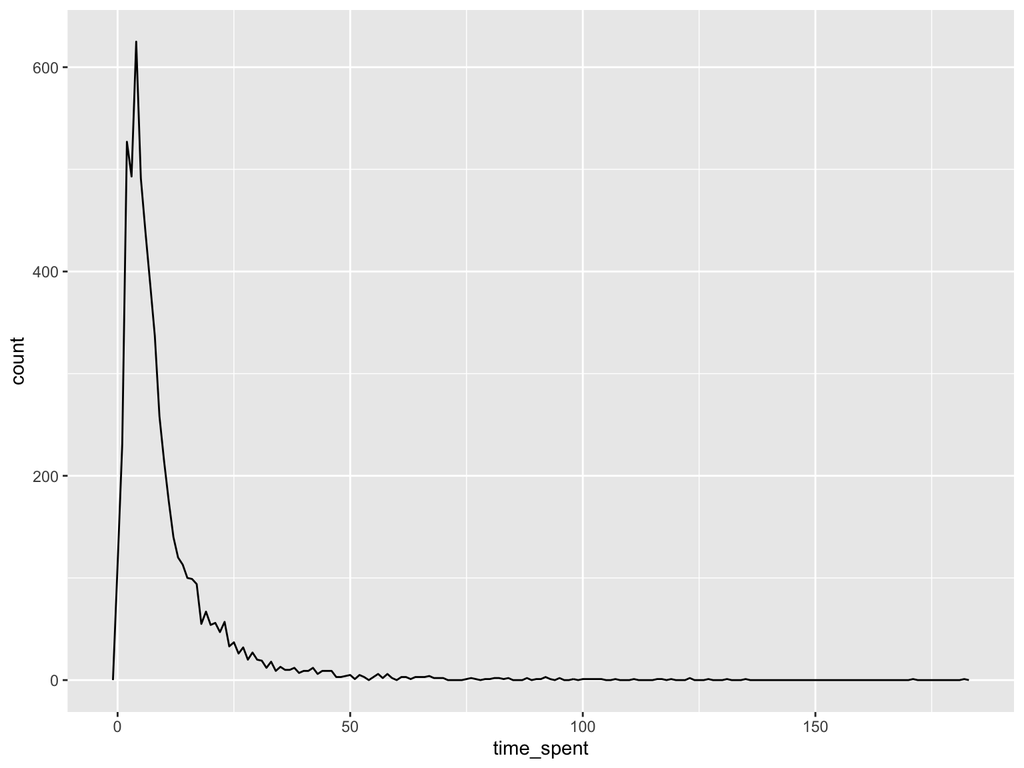

```r
  # And plot the frequency distribution of the time spent by the patients
  MIMIC3_adm_dis %>%
  ggplot(aes(time_spent)) +
    geom_freqpoly(binwidth = 1)
```

time difference can be little painful to work with when we are interested in durations.

The library lubridate provides an alternative which always uses seconds: the **duration**.

We can convert our variable into duration by using the function `as.duration()`.

```r
  # Convert the time spent as duration (in seconds)
  MIMIC3_adm_dis <- MIMIC3_adm_dis %>%
                    mutate(time_spent_in_seconds = as.duration(time_spent))
  as.tibble(MIMIC3_adm_dis)
```

```
## # A tibble: 5,770 x 5
##    hadm_id admittime  dischtime  time_spent time_spent_in_seconds
##      <int> <date>     <date>     <drtn>     <Duration>
##  1  110641 2150-06-24 2150-06-29  5 days    432000s (~5 days)
##  2  158569 2142-04-01 2142-04-08  7 days    604800s (~1 weeks)
##  3  120969 2196-02-02 2196-02-04  2 days    172800s (~2 days)
##  4  166401 2196-04-14 2196-04-17  3 days    259200s (~3 days)
##  5  116630 2162-03-02 2162-03-10  8 days    691200s (~1.14 weeks)
##  6  112077 2167-07-25 2167-07-30  5 days    432000s (~5 days)
##  7  190243 2146-04-06 2146-04-10  4 days    345600s (~4 days)
##  8  190659 2191-02-25 2191-04-25 59 days    5097600s (~8.43 weeks)
##  9  123010 2111-08-29 2111-09-03  5 days    432000s (~5 days)
## 10  188646 2185-06-17 2185-06-21  4 days    345600s (~4 days)
## # … with 5,760 more rows
```

Durations come with a bunch of convenient constructors:

```r
  # List the duration of 15s
  dseconds(15)
  # List the duration in 10 minutes
  dminutes(10)
  # List the duration in 12 hrs and 24 hours
  dhours(c(12, 24))
  # List the duration from 0 to 5 days
  ddays(0:5)
  # List the duration in 3 weeks
  dweeks(3)
  # List the duration in a year
  dyears(1)
```

```
## [1] "15s"
## [1] "600s (~10 minutes)"
## [1] "43200s (~12 hours)" "86400s (~1 days)"
## [1] "0s"                "86400s (~1 days)"  "172800s (~2 days)"
## [4] "259200s (~3 days)" "345600s (~4 days)" "432000s (~5 days)"
## [1] "1814400s (~3 weeks)"
## [1] "31536000s (~52.14 weeks)"
```

These constructors can help convert our years by a 200 year offset. Or alternatively we can use periods.

**Periods** are time spans but don’t have a fixed length in seconds, instead they work with “human” times, like days and months.

That allows them work in a more intuitive way. Like durations, periods can be created with a number of friendly constructor functions.

```r
  # Make 15s
  seconds(15)
  # Make 10m
  minutes(10)
  # Make 12 hrs and 24 hrs
  hours(c(12, 24))
  # Make 7 days
  days(7)
  # Make 1-6 months
  months(1:6)
  # Make 3 weeks
  weeks(3)
  # Make 1 year
  years(1)
```

```
## [1] "15S"
## [1] "10M 0S"
## [1] "12H 0M 0S" "24H 0M 0S"
## [1] "7d 0H 0M 0S"
## [1] "1m 0d 0H 0M 0S" "2m 0d 0H 0M 0S" "3m 0d 0H 0M 0S" "4m 0d 0H 0M 0S"
## [5] "5m 0d 0H 0M 0S" "6m 0d 0H 0M 0S"
## [1] "21d 0H 0M 0S"
## [1] "1y 0m 0d 0H 0M 0S"
```

You can add and multiply periods and add them to dates. Thus we can subtract a 200 year time peroid from our admission and discharge times:

```r
  # Makes times compatible with our times subtracting 200 years
  MIMIC3_adm_dis <- MIMIC3_adm_dis %>%
                    mutate(admission_time_minus_200 = ymd(admittime)-years(200),
                    dischtime_time_minus_200 = ymd(dischtime)-years(200)) %>%
                    select(admission_time_minus_200, dischtime_time_minus_200, everything())
  as.tibble(MIMIC3_adm_dis)
```

```
## # A tibble: 5,770 x 7
##    admission_time_… dischtime_time_… time_spent hadm_id admittime
##    <date>           <date>           <drtn>       <int> <date>
##  1 1950-06-24       1950-06-29        5 days     110641 2150-06-24
##  2 1942-04-01       1942-04-08        7 days     158569 2142-04-01
##  3 1996-02-02       1996-02-04        2 days     120969 2196-02-02
##  4 1996-04-14       1996-04-17        3 days     166401 2196-04-14
##  5 1962-03-02       1962-03-10        8 days     116630 2162-03-02
##  6 1967-07-25       1967-07-30        5 days     112077 2167-07-25
##  7 1946-04-06       1946-04-10        4 days     190243 2146-04-06
##  8 1991-02-25       1991-04-25       59 days     190659 2191-02-25
##  9 1911-08-29       1911-09-03        5 days     123010 2111-08-29
## 10 1985-06-17       1985-06-21        4 days     188646 2185-06-17
## # … with 5,760 more rows, and 2 more variables: dischtime <date>,
## #   time_spent_in_seconds <Duration>
```

What should `years(1) / days(1)` return?

Is it 365 or 366, since some years are leap years and periods are human interpretable values unlike duration?

R will throw a warning if we try to perfom this operation.

```r
  # Find years(1) / days(1)
  years(1) / days(1)
```

```
## estimate only: convert to intervals for accuracy
```

```
## [1] 365.25
```

Thus we have to use an **interval**.

An interval is a duration with an explicit starting point: that makes it precise so you can determine exactly how long it is:

```r
  # Find years(1) / days(1) by converting to interval
  next_year <- today() + years(1)
  (today() %--% next_year) / ddays(1)
```

```
## [1] 366
```

```r
  # Find years(1) / days(1) by converting to interval
  in2years <- today() + years(2)
  (next_year %--% in2years) / ddays(1)
```

```
## [1] 365
```

**Intervals** are defined by using the `%--%` operator.

Here is another example:  
Below we define two dates in the US Eastern time zone. The start day is March 11, 2017 at 5:21 AM. The end day is March 12, 2017 at the same time. Note that Daylight Savings began on March 12 at 2:00 AM.

```r
start <- mdy_hm("3-11-2017 5:21", tz = "US/Eastern")
end <- mdy_hm("3-12-2017 5:21", tz = "US/Eastern")

# Since we’re dealing with elapsed time between two dates,
# let’s start with Intervals. We can define an Interval using the %--% operator.
time.interval <- start %--% end
time.interval
```

```
## [1] 2017-03-11 05:21:00 EST--2017-03-12 05:21:00 EDT
```

Notice how Intervals print. They show the beginng date and end date. And also notice how the time zone changes from EST to EDT indicating that Daylight Savings has started.

```r
str(time.interval)
```

```
## Formal class 'Interval' [package "lubridate"] with 3 slots
##   ..@ .Data: num 82800
##   ..@ start: POSIXct[1:1], format: "2017-03-11 05:21:00"
##   ..@ tzone: chr "US/Eastern"
```

If we look at the structure of an Interval object we see it contains elapsed time in seconds, 82800, and the start date.

To create a Duration between these two dates, we can use the as.duration function.

```r
time.duration <- as.duration(time.interval)
time.duration
```

```
## [1] "82800s (~23 hours)"
```

Notice a Duration object prints the elapsed time in seconds as well as something a little friendlier to read, in this case hours. Because Daylight Savings went into effect at 2:00 AM during the interval, an hour was skipped. Thus the duration between these two time points is only 23 hours.

If we look at the structure of a Duration object we see it just contains elapsed time in seconds.

```r
str(time.duration)
```

```
## Formal class 'Duration' [package "lubridate"] with 1 slot
##   ..@ .Data: num 82800
```

We can create a Period from an Interval using the as.period function.

```r
time.period <- as.period(time.interval)
time.period
```

```
## [1] "1d 0H 0M 0S"
```

A Period prints elapsed time as integers in the form of years, months, weeks, days and so on. Notice this Period is 1 day long. While only 23 hours have technically elapsed since the start date, according to our clock one day has elapsed.

**Classwork/Homework**: Read section 16.5 Date-time components in the book R for Data Science.

### Tidying data

Same “kind of” data can be present in multiple columns that may denote a single variable.

To handle such situations we can use the `gather()` function from the [**tidyr**](https://cran.r-project.org/web/packages/tidyr/vignettes/tidy-data.html) package. The purpose of the this function is to aggregate such data into a new, single **pair** of variables. To accomplish this, we need three parameters:

- The set of columns that represent sub-classification/sub-variables.
- The name of a single variable that represents a larger class. This is called **a key**.
- The values that are present in the cells corresponding to the sub-variables.

Here is an example taken from the `gather()` help page:

```r
stocks <- tibble(
  time = as.Date('2009-01-01') + 0:9,
  X = rnorm(10, 0, 1),
  Y = rnorm(10, 0, 2),
  Z = rnorm(10, 0, 4)
)
stocks
```

```
## # A tibble: 10 x 4
##    time             X      Y       Z
##    <date>       <dbl>  <dbl>   <dbl>
##  1 2009-01-01  0.139   2.04  -0.0138
##  2 2009-01-02 -0.808   2.11  -6.38
##  3 2009-01-03  0.337  -0.503  4.15
##  4 2009-01-04 -0.182   0.125 -1.38
##  5 2009-01-05 -2.34   -1.93   1.83
##  6 2009-01-06 -0.0377  1.49   3.29
##  7 2009-01-07 -0.723  -0.174 10.3
##  8 2009-01-08 -0.235   0.714 -4.15
##  9 2009-01-09  0.300   2.76   6.66
## 10 2009-01-10 -0.934   1.46  -4.40
```

```r
# Gather all stocks data under one column:'price' and an added new factor:'stock'
# '-time' means to drop the 'time' variable from the list of variables to be processed.
# See the ... option from the help page.
stocks %>% gather(stock, price, -time) %>% mutate(stock = factor(stock)) %>%
  print() -> meltedStocks
```

```
## # A tibble: 30 x 3
##    time       stock   price
##    <date>     <fct>   <dbl>
##  1 2009-01-01 X      0.139
##  2 2009-01-02 X     -0.808
##  3 2009-01-03 X      0.337
##  4 2009-01-04 X     -0.182
##  5 2009-01-05 X     -2.34
##  6 2009-01-06 X     -0.0377
##  7 2009-01-07 X     -0.723
##  8 2009-01-08 X     -0.235
##  9 2009-01-09 X      0.300
## 10 2009-01-10 X     -0.934
## # … with 20 more rows
```

```r
# Show that now 'stock' serves as a factor
levels(meltedStocks$stock)
```

```
## [1] "X" "Y" "Z"
```

Now, let’s consider MIMIC3 admissions table. There are two variables - `edregtime` and `edouttime` (emergency department registration time and emergency department out time, respectively) that represents one variable: `time stamp in emergency`, a larger class of variable.

```r
  # Select subject_id, hadm_id, edregtime and edouttime variables
  MIMIC3_ADM_tibble <- MIMIC3_ADM %>% select(subject_id, hadm_id, edregtime, edouttime) %>% na.omit()
  as.tibble(MIMIC3_ADM_tibble)
```

```
## # A tibble: 3,065 x 4
##    subject_id hadm_id edregtime           edouttime
##         <int>   <int> <chr>               <chr>
##  1         84  166401 2196-04-13 22:23:00 2196-04-14 04:31:00
##  2         85  112077 2167-07-25 16:37:00 2167-07-25 20:46:00
##  3         88  123010 2111-08-29 01:44:00 2111-08-29 02:28:00
##  4         91  121205 2177-04-22 21:02:00 2177-04-23 04:03:00
##  5         94  183686 2176-02-25 10:35:00 2176-02-25 18:14:00
##  6         94  140037 2176-09-02 09:54:00 2176-09-02 17:56:00
##  7         95  160891 2157-12-25 12:24:00 2157-12-25 16:56:00
##  8         96  170324 2156-03-31 13:54:00 2156-03-31 14:45:00
##  9        101  175533 2196-09-26 12:50:00 2196-09-26 18:37:00
## 10        103  133550 2144-08-30 17:12:00 2144-08-31 00:39:00
## # … with 3,055 more rows
```

Let’s see how to use `gather()` using the MIMIC3 data set:

- The set of columns that represent sub-classification are the columns: `edregtime` and `edouttime`
- The key here is the ‘time stamp in emergency’. Let’s call this variable `EdTimeStamp`.
- The values here are the time stamp when registering and when checking-out of the emergency department. Lets call this variable `time`

Once we have these parameters, we can *gather* data:

```r
  # Gather edregtime and edouttime, to form variable "EdTimeStamp" with
  # value "time"
  MIMIC3_ADM_gather <- MIMIC3_ADM_tibble %>%
    gather("edregtime", "edouttime", key = "EdTimeStamp", value = "time")

# Showing table head
as.tibble(head(MIMIC3_ADM_gather, n=4))
## # A tibble: 4 x 4
##   subject_id hadm_id EdTimeStamp time
##        <int>   <int> <chr>       <chr>
## 1         84  166401 edregtime   2196-04-13 22:23:00
## 2         85  112077 edregtime   2167-07-25 16:37:00
## 3         88  123010 edregtime   2111-08-29 01:44:00
## 4         91  121205 edregtime   2177-04-22 21:02:00

# Showing table tail
as.tibble(tail(MIMIC3_ADM_gather, n=4))
## # A tibble: 4 x 4
##   subject_id hadm_id EdTimeStamp time
##        <int>   <int> <chr>       <chr>
## 1      90521  195402 edouttime   2197-07-08 13:45:00
## 2      90535  151788 edouttime   2137-11-19 22:12:00
## 3      90538  105088 edouttime   2146-03-10 11:47:00
## 4      99781  147562 edouttime   2133-08-01 20:38:00
```

```r
# An example for the duplication in the number of rows for each subject_id (here for id 88)
MIMIC3_ADM_gather %>% filter(subject_id == 88)
```

```
##   subject_id hadm_id EdTimeStamp                time
## 1         88  123010   edregtime 2111-08-29 01:44:00
## 2         88  123010   edouttime 2111-08-29 02:28:00
```

**Classwork/Homework**: Find the number of times each patient was registered in emergency department.

**Spreading** is the opposite of gathering.

We use it when an observation is scattered across multiple rows.

For example, in the above data set, the patient denoted by `subject_id` can have several hospital admission id `hadm_id` depending on how many times they were admitted in the hospital.

To spread this data, we first analyse the representation in similar way to `gather()`. This time, however, we only need two parameters:

- The column that contains the key column. Here, it’s `subject_id`.
- The column that contains multiple values for the key column, the values column. Here it’s `hadm_id`.

Once we have these two parameters we can *spread* the data:

```r
  # Spread each patient (subject_id) for the hospital admission id - hadm_id
  MIMIC3_ADM_spread <- MIMIC3_ADM_tibble %>% head() %>%
    spread(key = subject_id, value = hadm_id) %>%
    select(`edregtime`, `edouttime`, '94', everything())
  as.tibble(MIMIC3_ADM_spread)
```

```
## # A tibble: 6 x 7
##   edregtime           edouttime            `94`   `84`   `85`   `88`   `91`
##   <chr>               <chr>               <int>  <int>  <int>  <int>  <int>
## 1 2111-08-29 01:44:00 2111-08-29 02:28:…     NA     NA     NA 123010     NA
## 2 2167-07-25 16:37:00 2167-07-25 20:46:…     NA     NA 112077     NA     NA
## 3 2176-02-25 10:35:00 2176-02-25 18:14:… 183686     NA     NA     NA     NA
## 4 2176-09-02 09:54:00 2176-09-02 17:56:… 140037     NA     NA     NA     NA
## 5 2177-04-22 21:02:00 2177-04-23 04:03:…     NA     NA     NA     NA 121205
## 6 2196-04-13 22:23:00 2196-04-14 04:31:…     NA 166401     NA     NA     NA
```

We immediately see that patient no. 94 had two admissions in the hospital as emergency visits.

`separate()` pulls apart one column into multiple columns, by splitting wherever a separator character appears.

For example, consider the `admissions_location` variable. Its made of 9 possible values:

- EMERGENCY ROOM ADMIT
- TRANSFER FROM HOSP/EXTRAM
- TRANSFER FROM OTHER HEALT
- CLINIC REFERRAL/PREMATURE
- INFO NOT AVAILABLE
- TRANSFER FROM SKILLED NUR
- TRSF WITHIN THIS FACILITY
- HMO REFERRAL/SICK
- PHYS REFERRAL/NORMAL DELI

```r
  # Separate admission_location information
  MIMIC3_ADM_LOC_SEP <- MIMIC3_ADM %>% select(admission_location) %>%
    separate(admission_location, into = c("Info1", "Info2"), sep = "/", convert = FALSE)
  as.tibble(MIMIC3_ADM_LOC_SEP)
```

```
## # A tibble: 5,770 x 2
##    Info1                Info2
##    <chr>                <chr>
##  1 PHYS REFERRAL        NORMAL DELI
##  2 TRANSFER FROM HOSP   EXTRAM
##  3 PHYS REFERRAL        NORMAL DELI
##  4 EMERGENCY ROOM ADMIT <NA>
##  5 CLINIC REFERRAL      PREMATURE
##  6 CLINIC REFERRAL      PREMATURE
##  7 PHYS REFERRAL        NORMAL DELI
##  8 PHYS REFERRAL        NORMAL DELI
##  9 EMERGENCY ROOM ADMIT <NA>
## 10 PHYS REFERRAL        NORMAL DELI
## # … with 5,760 more rows
```

By default `seperate()` would coerce into charector vectors even if we seperate numerical variables. To retain numerical type, we have to set `convert = TRUE` argument.

`unite()` is the inverse of `separate()`: it combines multiple columns into a single column.

For example, in the above data set we can *unite* hospital admission id `hadm_id` and the admission type `admission_type` to tie a reason why the patient got admitted. By default the unite will use underscore.

This can be overridden by using a seperator argument. This is done as follows:

```r
  # Unite hadm_id and admission_type
  MIMIC3_ADM_LOC_UNITE <- MIMIC3_ADM %>% select(subject_id, hadm_id, admission_type) %>%
    unite(reason, hadm_id, admission_type, sep=":")
  as.tibble(MIMIC3_ADM_LOC_UNITE)
```

```
## # A tibble: 5,770 x 2
##    subject_id reason
##         <int> <chr>
##  1         82 110641:NEWBORN
##  2         83 158569:URGENT
##  3         84 120969:ELECTIVE
##  4         84 166401:EMERGENCY
##  5         85 116630:EMERGENCY
##  6         85 112077:EMERGENCY
##  7         86 190243:ELECTIVE
##  8         87 190659:NEWBORN
##  9         88 123010:EMERGENCY
## 10         89 188646:NEWBORN
## # … with 5,760 more rows
```

#### Missing values

Missing values can be:

1. Explicit and flagged with NA
2. Implicit with values absent

Consider this data:

```r
  # Make a tibble reporting the data on people affected with influenza
  influenza <- tibble(
    year   = c(2015, 2015, 2015, 2015, 2016, 2016, 2016),
    qtr    = c(   1,    2,    3,    4,    2,    3,    4),
    no_sick = c(800, 450, 377,   NA, 900, 1300, 1257)
  )
  influenza
```

```
## # A tibble: 7 x 3
##    year   qtr no_sick
##   <dbl> <dbl>   <dbl>
## 1  2015     1     800
## 2  2015     2     450
## 3  2015     3     377
## 4  2015     4      NA
## 5  2016     2     900
## 6  2016     3    1300
## 7  2016     4    1257
```

There are two missing values in this dataset:

The no of sick people for the fourth quarter of 2015 is explicitly missing, because the cell where its value should be instead contains NA.

The no of sick people for the first quarter of 2016 is implicitly missing, because it simply does not appear in the dataset.

There are several ways we can deal with the missing values.

1. We can make the implicit missing value explicit by putting years in the columns:

```r
  # Spread the data to make implicit absense explicit
  influenza %>%
    spread(year, no_sick)
```

```
## # A tibble: 4 x 3
##     qtr `2015` `2016`
##   <dbl>  <dbl>  <dbl>
## 1     1    800     NA
## 2     2    450    900
## 3     3    377   1300
## 4     4     NA   1257
```

2. Explicit missing values may not be important in other representations of the data so we can set `na.rm = TRUE` in `gather()` to turn explicit missing values implicit:

```r
  # Spread the data to make implicit absense explicit and
  # gather with na.rm = TRUE to turn explicit missing values implicit
  influenza %>%
    spread(year, no_sick) %>%
    gather(year, no_sick, `2015`:`2016`, na.rm = TRUE)
```

```
## # A tibble: 6 x 3
##     qtr year  no_sick
##   <dbl> <chr>   <dbl>
## 1     1 2015      800
## 2     2 2015      450
## 3     3 2015      377
## 4     2 2016      900
## 5     3 2016     1300
## 6     4 2016     1257
```

3. We can use `complete()` which takes a set of columns, and finds all unique combinations. It then ensures the original dataset contains all those values, filling in explicit NAs where necessary:

```r
  # Complete the data by finding the combinations and replacing NA
  influenza %>%
    complete(year, qtr)
```

```
## # A tibble: 8 x 3
##    year   qtr no_sick
##   <dbl> <dbl>   <dbl>
## 1  2015     1     800
## 2  2015     2     450
## 3  2015     3     377
## 4  2015     4      NA
## 5  2016     1      NA
## 6  2016     2     900
## 7  2016     3    1300
## 8  2016     4    1257
```

4. Or we can use `fill()` which takes a set of columns where you want missing values to be replaced by the most recent non-missing value (sometimes called last observation carried forward).

```r
  # Fill NA with the most recent value found - 377 in this case
  influenza %>%
    fill(no_sick)
```

```
## # A tibble: 7 x 3
##    year   qtr no_sick
##   <dbl> <dbl>   <dbl>
## 1  2015     1     800
## 2  2015     2     450
## 3  2015     3     377
## 4  2015     4     377
## 5  2016     2     900
## 6  2016     3    1300
## 7  2016     4    1257
```

#### Case study: TB data from WHO

The following case study illustrates the typical process involved in tidying up real world data.

The data comes from the 2014 World Health Organization Global Tuberculosis Report, which can be downloaded from [WHO TB Data](http://www.who.int/tb/country/data/download/en/).

The data is a part of *tidyverse* package, so you don’t have to download it.

Just querying the data results as follows:

```r
  # Query WHO TB data
  who
```

```
## # A tibble: 7,240 x 60
##    country iso2  iso3   year new_sp_m014 new_sp_m1524 new_sp_m2534
##    <chr>   <chr> <chr> <int>       <int>        <int>        <int>
##  1 Afghan… AF    AFG    1980          NA           NA           NA
##  2 Afghan… AF    AFG    1981          NA           NA           NA
##  3 Afghan… AF    AFG    1982          NA           NA           NA
##  4 Afghan… AF    AFG    1983          NA           NA           NA
##  5 Afghan… AF    AFG    1984          NA           NA           NA
##  6 Afghan… AF    AFG    1985          NA           NA           NA
##  7 Afghan… AF    AFG    1986          NA           NA           NA
##  8 Afghan… AF    AFG    1987          NA           NA           NA
##  9 Afghan… AF    AFG    1988          NA           NA           NA
## 10 Afghan… AF    AFG    1989          NA           NA           NA
## # … with 7,230 more rows, and 53 more variables: new_sp_m3544 <int>,
## #   new_sp_m4554 <int>, new_sp_m5564 <int>, new_sp_m65 <int>,
## #   new_sp_f014 <int>, new_sp_f1524 <int>, new_sp_f2534 <int>,
## #   new_sp_f3544 <int>, new_sp_f4554 <int>, new_sp_f5564 <int>,
## #   new_sp_f65 <int>, new_sn_m014 <int>, new_sn_m1524 <int>,
## #   new_sn_m2534 <int>, new_sn_m3544 <int>, new_sn_m4554 <int>,
## #   new_sn_m5564 <int>, new_sn_m65 <int>, new_sn_f014 <int>,
## #   new_sn_f1524 <int>, new_sn_f2534 <int>, new_sn_f3544 <int>,
## #   new_sn_f4554 <int>, new_sn_f5564 <int>, new_sn_f65 <int>,
## #   new_ep_m014 <int>, new_ep_m1524 <int>, new_ep_m2534 <int>,
## #   new_ep_m3544 <int>, new_ep_m4554 <int>, new_ep_m5564 <int>,
## #   new_ep_m65 <int>, new_ep_f014 <int>, new_ep_f1524 <int>,
## #   new_ep_f2534 <int>, new_ep_f3544 <int>, new_ep_f4554 <int>,
## #   new_ep_f5564 <int>, new_ep_f65 <int>, newrel_m014 <int>,
## #   newrel_m1524 <int>, newrel_m2534 <int>, newrel_m3544 <int>,
## #   newrel_m4554 <int>, newrel_m5564 <int>, newrel_m65 <int>,
## #   newrel_f014 <int>, newrel_f1524 <int>, newrel_f2534 <int>,
## #   newrel_f3544 <int>, newrel_f4554 <int>, newrel_f5564 <int>,
## #   newrel_f65 <int>
```

It contains redundant columns, odd variable codes, and many missing values.

The variables - country, iso2, and iso3 redundantly specify the country.

We don’t know what the variables *new_sp_m014*, *new_ep_m014*, *new_ep_f014* mean.

Therefore, we look them up in the given dictionary.

`iso2` and `iso3` are ISO standard country/territory codes. Also the variables that start with `new` are new cases.

In particular,

1. The first three letters of each column denote whether the column contains new or old cases of TB. In this dataset, each column contains new cases.
2. The next two letters describe the type of TB:
   1. rel stands for cases of relapse
   2. ep stands for cases of extrapulmonary TB
   3. sn stands for cases of pulmonary TB that could not be diagnosed by a pulmonary smear (smear negative)
   4. sp stands for cases of pulmonary TB that could be diagnosed be a pulmonary smear (smear positive)
   5. The sixth letter gives the sex of TB patients. The dataset groups cases by males (m) and females (f).
3. The remaining numbers gives the age group. The dataset groups cases into seven age groups:
   1. 014 = 0 – 14 years old
   2. 1524 = 15 – 24 years old
   3. 2534 = 25 – 34 years old
   4. 3544 = 35 – 44 years old
   5. 4554 = 45 – 54 years old
   6. 5564 = 55 – 64 years old
   7. 65 = 65 or older

Thus we need to separate them. But first since each of these variables contains count of new cases, a natural way to organize them would be to gather these variables.

We can make a meta-variable “group” and “case-count” to reflect this gathering removing missing values `NA`:

```r
  # Gather "new_" variables, removing NA, grouping them up and counting cases
  who_gathered <- who %>%
    gather(new_sp_m014:newrel_f65, key = "group", value = "case-count", na.rm = TRUE)
  as.tibble(who_gathered)
```

```
## # A tibble: 76,046 x 6
##    country     iso2  iso3   year group       `case-count`
##    <chr>       <chr> <chr> <int> <chr>              <int>
##  1 Afghanistan AF    AFG    1997 new_sp_m014            0
##  2 Afghanistan AF    AFG    1998 new_sp_m014           30
##  3 Afghanistan AF    AFG    1999 new_sp_m014            8
##  4 Afghanistan AF    AFG    2000 new_sp_m014           52
##  5 Afghanistan AF    AFG    2001 new_sp_m014          129
##  6 Afghanistan AF    AFG    2002 new_sp_m014           90
##  7 Afghanistan AF    AFG    2003 new_sp_m014          127
##  8 Afghanistan AF    AFG    2004 new_sp_m014          139
##  9 Afghanistan AF    AFG    2005 new_sp_m014          151
## 10 Afghanistan AF    AFG    2006 new_sp_m014          193
## # … with 76,036 more rows
```

Also observe that for `rel` we don’t have underscore, whereas for `ep` we have underscore after `new`. Thus, we need to fix these to get consistent variables:

```r
  # Replace newrel by new_rel
  who_rel_replaced <- who_gathered %>%
    mutate(group = stringr::str_replace(group, "newrel", "new_rel"))
  as.tibble(who_rel_replaced)
```

```
## # A tibble: 76,046 x 6
##    country     iso2  iso3   year group       `case-count`
##    <chr>       <chr> <chr> <int> <chr>              <int>
##  1 Afghanistan AF    AFG    1997 new_sp_m014            0
##  2 Afghanistan AF    AFG    1998 new_sp_m014           30
##  3 Afghanistan AF    AFG    1999 new_sp_m014            8
##  4 Afghanistan AF    AFG    2000 new_sp_m014           52
##  5 Afghanistan AF    AFG    2001 new_sp_m014          129
##  6 Afghanistan AF    AFG    2002 new_sp_m014           90
##  7 Afghanistan AF    AFG    2003 new_sp_m014          127
##  8 Afghanistan AF    AFG    2004 new_sp_m014          139
##  9 Afghanistan AF    AFG    2005 new_sp_m014          151
## 10 Afghanistan AF    AFG    2006 new_sp_m014          193
## # … with 76,036 more rows
```

We can now seperate the variables to reflect the type of TB, gender and the age group. First we seperate by underscore:

```r
  # First we seperate by underscore
  who_seperated_by_underscore <- who_rel_replaced %>%
    separate(group, c("new", "type", "sexage"), sep = "_")
  as.tibble(who_seperated_by_underscore)
```

```
## # A tibble: 76,046 x 8
##    country     iso2  iso3   year new   type  sexage `case-count`
##    <chr>       <chr> <chr> <int> <chr> <chr> <chr>         <int>
##  1 Afghanistan AF    AFG    1997 new   sp    m014              0
##  2 Afghanistan AF    AFG    1998 new   sp    m014             30
##  3 Afghanistan AF    AFG    1999 new   sp    m014              8
##  4 Afghanistan AF    AFG    2000 new   sp    m014             52
##  5 Afghanistan AF    AFG    2001 new   sp    m014            129
##  6 Afghanistan AF    AFG    2002 new   sp    m014             90
##  7 Afghanistan AF    AFG    2003 new   sp    m014            127
##  8 Afghanistan AF    AFG    2004 new   sp    m014            139
##  9 Afghanistan AF    AFG    2005 new   sp    m014            151
## 10 Afghanistan AF    AFG    2006 new   sp    m014            193
## # … with 76,036 more rows
```

And then by the gender and age group which are linked together, so we can use `sep = 1` argument:

```r
  # Then we seperate by gender and age using "sep = 1"
  who_seperated_by_gender_age <- who_seperated_by_underscore %>%
    separate(sexage, c("sex", "age"), sep = 1)
  as.tibble(who_seperated_by_gender_age)
```

```
## # A tibble: 76,046 x 9
##    country     iso2  iso3   year new   type  sex   age   `case-count`
##    <chr>       <chr> <chr> <int> <chr> <chr> <chr> <chr>        <int>
##  1 Afghanistan AF    AFG    1997 new   sp    m     014              0
##  2 Afghanistan AF    AFG    1998 new   sp    m     014             30
##  3 Afghanistan AF    AFG    1999 new   sp    m     014              8
##  4 Afghanistan AF    AFG    2000 new   sp    m     014             52
##  5 Afghanistan AF    AFG    2001 new   sp    m     014            129
##  6 Afghanistan AF    AFG    2002 new   sp    m     014             90
##  7 Afghanistan AF    AFG    2003 new   sp    m     014            127
##  8 Afghanistan AF    AFG    2004 new   sp    m     014            139
##  9 Afghanistan AF    AFG    2005 new   sp    m     014            151
## 10 Afghanistan AF    AFG    2006 new   sp    m     014            193
## # … with 76,036 more rows
```

We can then drop the unwanted variables, such as `new`, `iso2`, `iso3` etc. Thus, our data will be tidy after this:

```r
  # Drop "new" and "iso" variables and tidy the data
  tidy_who <- who_seperated_by_gender_age %>%
    select(-new, -iso2, -iso3)
  as.tibble(tidy_who)
```

```
## # A tibble: 76,046 x 6
##    country      year type  sex   age   `case-count`
##    <chr>       <int> <chr> <chr> <chr>        <int>
##  1 Afghanistan  1997 sp    m     014              0
##  2 Afghanistan  1998 sp    m     014             30
##  3 Afghanistan  1999 sp    m     014              8
##  4 Afghanistan  2000 sp    m     014             52
##  5 Afghanistan  2001 sp    m     014            129
##  6 Afghanistan  2002 sp    m     014             90
##  7 Afghanistan  2003 sp    m     014            127
##  8 Afghanistan  2004 sp    m     014            139
##  9 Afghanistan  2005 sp    m     014            151
## 10 Afghanistan  2006 sp    m     014            193
## # … with 76,036 more rows
```

#### Relational data

Usually data in the real world comes in different tables.

Multiple tables of data are called relational data because it is the relations, not just the individual datasets, that are important.

Combining data in multiple tables is an imporant part of the wrangling process. Usually these combinations are facilitated by *joins*.

There are three families of joins that are designed to work with relational data:

1. Mutating joins: these joins add new variables to one data frame based on the presence of data from the other data table.
2. Filtering joins: these filter observations from one data frame based on whether or not they match an observation in the other table.
3. Set operations: these operations treat observations as if they were set elements.

A variable that connects two tables are called *keys*. There are several types of keys:

1. A *primary key* uniquely identifies an observation in its own table.
2. A *foreign key* uniquely identifies an observation in another table.
3. A *surrogate key* uniquely identifies an observation in the absence of a primary key. They can be created, for instance using `mutate()` and `row_number()`.

**Note**: A primary key can also be a foreign key.

Once we identify if a variable is a key one way to verify is to use the `count()` function and look for entries where `n` is greater than one:

```r
  # Verify if hadm_id is a primary key
  MIMIC3_ADM %>%
    count(hadm_id) %>%
    filter(n > 1)
```

```
## # A tibble: 0 x 2
## # … with 2 variables: hadm_id <int>, n <int>
```

```r
  # Verify if subject_id is a primary key
  is_subject_id_key <- MIMIC3_ADM %>%
                        count(subject_id) %>%
                        filter(n > 1)
  as.tibble(is_subject_id_key)
```

```
## # A tibble: 729 x 2
##    subject_id     n
##         <int> <int>
##  1         84     2
##  2         85     2
##  3         94     2
##  4        103     2
##  5        105     2
##  6        107     3
##  7        109     8
##  8        426     2
##  9        433     4
## 10        434     2
## # … with 719 more rows
```

To describe the joins, we will work with input events data set from MIMIC3. A meta level description of the table is given as:

*Inputs and outputs are extremely useful when studying intensive care unit patients. Inputs are any fluids which have been administered to the patient: such as oral or tube feedings or intravenous solutions containing medications.*

A description of input events table is given [here](https://mimic.physionet.org/mimicdata/io/).

```r
  # Load the package RCurl
  library(RCurl)
  # Import the input events data set in MIMIC3 from GitHub;
  URL_text_1 <- "https://raw.githubusercontent.com/kannan-kasthuri/kannan-kasthuri.github.io"
  URL_text_2 <- "/master/Datasets/MIMIC3/inputevents_cv.csv"
  URL <- paste(URL_text_1,URL_text_2, sep="")
  MIMIC3_INE <- read.csv(text=getURL(URL))
  # Observe the structure
  as.tibble(MIMIC3_INE)
```

```
## # A tibble: 19,369 x 22
##    row_id subject_id hadm_id icustay_id charttime itemid amount amountuom
##     <int>      <int>   <int>      <int> <fct>      <int>  <dbl> <fct>
##  1  50508      15239  134445     208022 2186-07-…  30056     60 ml
##  2  50509      15239  134445     208022 2186-07-…  30056    120 ml
##  3  50510      15239  134445     208022 2186-07-…  30056    120 ml
##  4  50511      15239  134445     208022 2186-07-…  30056    400 ml
##  5  50512      15239  134445     208022 2186-07-…  30056    240 ml
##  6  50513      15239  134445     208022 2186-07-…  30056    240 ml
##  7  50514      15239  134445     208022 2186-07-…  30056    100 ml
##  8  50515      15239  134445     208022 2186-07-…  30056    100 ml
##  9  50516      15239  134445     208022 2186-07-…  30056     60 ml
## 10  50517      15239  134445     208022 2186-07-…  30056    100 ml
## # … with 19,359 more rows, and 14 more variables: rate <dbl>,
## #   rateuom <fct>, storetime <fct>, cgid <int>, orderid <int>,
## #   linkorderid <int>, stopped <fct>, newbottle <int>,
## #   originalamount <dbl>, originalamountuom <fct>, originalroute <fct>,
## #   originalrate <dbl>, originalrateuom <fct>, originalsite <fct>
```

##### Inner join (mutating joins)

Mutating inner join can be described by the following figure:

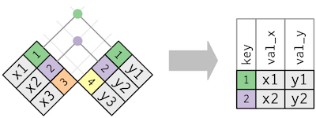

The following code computes the inner join of admissionas and input events cv table:

```r
  # Inner join of admissions table and input events (cv) table using the key "hadm_id"
  MIMIC_ADM_INE_inner_join <- MIMIC3_ADM %>%
                                inner_join(MIMIC3_INE, by = "hadm_id")

  as.tibble(MIMIC_ADM_INE_inner_join)
```

```
## # A tibble: 1,805 x 40
##    row_id.x subject_id.x hadm_id admittime  dischtime  deathtime
##       <int>        <int>   <int> <date>     <date>     <chr>
##  1       93           91  121205 2177-04-23 2177-05-10 2177-05-…
##  2       94           92  142807 2122-12-13 2123-03-04 <NA>
##  3       94           92  142807 2122-12-13 2123-03-04 <NA>
##  4       94           92  142807 2122-12-13 2123-03-04 <NA>
##  5       94           92  142807 2122-12-13 2123-03-04 <NA>
##  6       94           92  142807 2122-12-13 2123-03-04 <NA>
##  7       94           92  142807 2122-12-13 2123-03-04 <NA>
##  8       94           92  142807 2122-12-13 2123-03-04 <NA>
##  9       94           92  142807 2122-12-13 2123-03-04 <NA>
## 10       94           92  142807 2122-12-13 2123-03-04 <NA>
## # … with 1,795 more rows, and 34 more variables: admission_type <chr>,
## #   admission_location <chr>, discharge_location <chr>, insurance <chr>,
## #   language <chr>, religion <chr>, marital_status <chr>, ethnicity <chr>,
## #   edregtime <chr>, edouttime <chr>, diagnosis <chr>,
## #   hospital_expire_flag <int>, has_chartevents_data <int>,
## #   row_id.y <int>, subject_id.y <int>, icustay_id <int>, charttime <fct>,
## #   itemid <int>, amount <dbl>, amountuom <fct>, rate <dbl>,
## #   rateuom <fct>, storetime <fct>, cgid <int>, orderid <int>,
## #   linkorderid <int>, stopped <fct>, newbottle <int>,
## #   originalamount <dbl>, originalamountuom <fct>, originalroute <fct>,
## #   originalrate <dbl>, originalrateuom <fct>, originalsite <fct>
```

##### Outer joins (mutating joins)

There are three types of outer joins:

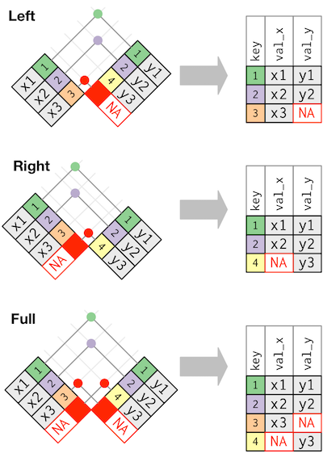

Left join admissions and input events table:

```r
  # Left join admissions table and input events (cv) table using the key "hadm_id"
  MIMIC_ADM_INE_left_join <- MIMIC3_ADM %>%
                                left_join(MIMIC3_INE, by = "hadm_id")

  as.tibble(MIMIC_ADM_INE_left_join)
```

```
## # A tibble: 7,179 x 40
##    row_id.x subject_id.x hadm_id admittime  dischtime  deathtime
##       <int>        <int>   <int> <date>     <date>     <chr>
##  1       83           82  110641 2150-06-24 2150-06-29 <NA>
##  2       84           83  158569 2142-04-01 2142-04-08 <NA>
##  3       85           84  120969 2196-02-02 2196-02-04 <NA>
##  4       86           84  166401 2196-04-14 2196-04-17 2196-04-…
##  5       87           85  116630 2162-03-02 2162-03-10 <NA>
##  6       88           85  112077 2167-07-25 2167-07-30 <NA>
##  7       89           86  190243 2146-04-06 2146-04-10 <NA>
##  8       90           87  190659 2191-02-25 2191-04-25 <NA>
##  9       91           88  123010 2111-08-29 2111-09-03 <NA>
## 10       92           89  188646 2185-06-17 2185-06-21 <NA>
## # … with 7,169 more rows, and 34 more variables: admission_type <chr>,
## #   admission_location <chr>, discharge_location <chr>, insurance <chr>,
## #   language <chr>, religion <chr>, marital_status <chr>, ethnicity <chr>,
## #   edregtime <chr>, edouttime <chr>, diagnosis <chr>,
## #   hospital_expire_flag <int>, has_chartevents_data <int>,
## #   row_id.y <int>, subject_id.y <int>, icustay_id <int>, charttime <fct>,
## #   itemid <int>, amount <dbl>, amountuom <fct>, rate <dbl>,
## #   rateuom <fct>, storetime <fct>, cgid <int>, orderid <int>,
## #   linkorderid <int>, stopped <fct>, newbottle <int>,
## #   originalamount <dbl>, originalamountuom <fct>, originalroute <fct>,
## #   originalrate <dbl>, originalrateuom <fct>, originalsite <fct>
```

Right join admissions and input events table:

```r
  # Right join admissions table and input events (cv) table using the key "hadm_id"
  MIMIC_ADM_INE_right_join <- MIMIC3_ADM %>%
                                right_join(MIMIC3_INE, by = "hadm_id")

  as.tibble(MIMIC_ADM_INE_right_join)
```

```
## # A tibble: 19,369 x 40
##    row_id.x subject_id.x hadm_id admittime  dischtime  deathtime
##       <int>        <int>   <int> <date>     <date>     <chr>
##  1       NA           NA  134445 NA         NA         <NA>
##  2       NA           NA  134445 NA         NA         <NA>
##  3       NA           NA  134445 NA         NA         <NA>
##  4       NA           NA  134445 NA         NA         <NA>
##  5       NA           NA  134445 NA         NA         <NA>
##  6       NA           NA  134445 NA         NA         <NA>
##  7       NA           NA  134445 NA         NA         <NA>
##  8       NA           NA  134445 NA         NA         <NA>
##  9       NA           NA  134445 NA         NA         <NA>
## 10       NA           NA  134445 NA         NA         <NA>
## # … with 19,359 more rows, and 34 more variables: admission_type <chr>,
## #   admission_location <chr>, discharge_location <chr>, insurance <chr>,
## #   language <chr>, religion <chr>, marital_status <chr>, ethnicity <chr>,
## #   edregtime <chr>, edouttime <chr>, diagnosis <chr>,
## #   hospital_expire_flag <int>, has_chartevents_data <int>,
## #   row_id.y <int>, subject_id.y <int>, icustay_id <int>, charttime <fct>,
## #   itemid <int>, amount <dbl>, amountuom <fct>, rate <dbl>,
## #   rateuom <fct>, storetime <fct>, cgid <int>, orderid <int>,
## #   linkorderid <int>, stopped <fct>, newbottle <int>,
## #   originalamount <dbl>, originalamountuom <fct>, originalroute <fct>,
## #   originalrate <dbl>, originalrateuom <fct>, originalsite <fct>
```

Full join admissions and input events table:

```r
  # Full join admissions table and input events (cv) table using the key "hadm_id"
  MIMIC_ADM_INE_full_join <- MIMIC3_ADM %>%
                                full_join(MIMIC3_INE, by = "hadm_id")

  as.tibble(MIMIC_ADM_INE_full_join)
```

```
## # A tibble: 24,743 x 40
##    row_id.x subject_id.x hadm_id admittime  dischtime  deathtime
##       <int>        <int>   <int> <date>     <date>     <chr>
##  1       83           82  110641 2150-06-24 2150-06-29 <NA>
##  2       84           83  158569 2142-04-01 2142-04-08 <NA>
##  3       85           84  120969 2196-02-02 2196-02-04 <NA>
##  4       86           84  166401 2196-04-14 2196-04-17 2196-04-…
##  5       87           85  116630 2162-03-02 2162-03-10 <NA>
##  6       88           85  112077 2167-07-25 2167-07-30 <NA>
##  7       89           86  190243 2146-04-06 2146-04-10 <NA>
##  8       90           87  190659 2191-02-25 2191-04-25 <NA>
##  9       91           88  123010 2111-08-29 2111-09-03 <NA>
## 10       92           89  188646 2185-06-17 2185-06-21 <NA>
## # … with 24,733 more rows, and 34 more variables: admission_type <chr>,
## #   admission_location <chr>, discharge_location <chr>, insurance <chr>,
## #   language <chr>, religion <chr>, marital_status <chr>, ethnicity <chr>,
## #   edregtime <chr>, edouttime <chr>, diagnosis <chr>,
## #   hospital_expire_flag <int>, has_chartevents_data <int>,
## #   row_id.y <int>, subject_id.y <int>, icustay_id <int>, charttime <fct>,
## #   itemid <int>, amount <dbl>, amountuom <fct>, rate <dbl>,
## #   rateuom <fct>, storetime <fct>, cgid <int>, orderid <int>,
## #   linkorderid <int>, stopped <fct>, newbottle <int>,
## #   originalamount <dbl>, originalamountuom <fct>, originalroute <fct>,
## #   originalrate <dbl>, originalrateuom <fct>, originalsite <fct>
```

**Note**: By default, `by = NULL`, which will use all common variables that appear in both tables as keys. This is called *natural join*. We can also use `by = c("a" = "b")`. This will match variable `a` in the first table to variable `b` in the second table.

##### Semi join (filtering joins)

`semi_join(table1, table2, by = "k")` would keep all observations in table 1 that have a match in table 2 identified by the key “k”.

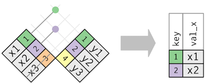

Thus, in our tables:

```r
  # Semi join admissions table and input events (cv) table using the key "hadm_id"
  MIMIC_ADM_INE_semi_join <- MIMIC3_ADM %>%
                                semi_join(MIMIC3_INE, by = "hadm_id")

  as.tibble(MIMIC_ADM_INE_semi_join)
```

```
## # A tibble: 396 x 19
##    row_id subject_id hadm_id admittime  dischtime  deathtime admission_type
##     <int>      <int>   <int> <date>     <date>     <chr>     <chr>
##  1     93         91  121205 2177-04-23 2177-05-10 2177-05-… EMERGENCY
##  2     94         92  142807 2122-12-13 2123-03-04 <NA>      NEWBORN
##  3     95         93  160481 2128-03-17 2128-06-17 <NA>      NEWBORN
##  4     96         94  183686 2176-02-25 2176-02-29 <NA>      EMERGENCY
##  5     99         96  170324 2156-03-31 2156-04-29 <NA>      EMERGENCY
##  6    104        101  175533 2196-09-26 2196-10-12 2196-10-… EMERGENCY
##  7    548        427  101274 2170-03-26 2170-04-01 <NA>      EMERGENCY
##  8    549        428  132541 2123-10-25 2123-12-20 <NA>      NEWBORN
##  9    556        433  163523 2164-08-13 2164-08-17 2164-08-… EMERGENCY
## 10    558        434  175451 2101-08-31 2101-09-16 <NA>      EMERGENCY
## # … with 386 more rows, and 12 more variables: admission_location <chr>,
## #   discharge_location <chr>, insurance <chr>, language <chr>,
## #   religion <chr>, marital_status <chr>, ethnicity <chr>,
## #   edregtime <chr>, edouttime <chr>, diagnosis <chr>,
## #   hospital_expire_flag <int>, has_chartevents_data <int>
```

this would result in keeping the observations in admissions that are present in input cv.

This is particularly useful if we have a result in one table that we want to analyze related data in the other table.

The opposite of `semi_join()` is the `anti-join(table1, table2, by = "k")`, where we would retain only the observations in table 1 that **does not** have a match in table 2, identified by the key “k”.

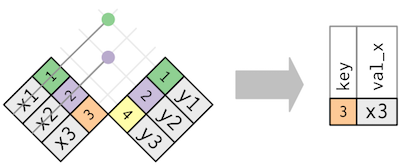

In our data tables, this would pull out all the entries in admissions table where hospital admissions id (`hadm_id`) is not present in the input events (cv) table.

```r
  # Anti join admissions table and input events (cv) table using the key "hadm_id"
  MIMIC_ADM_INE_anti_join <- MIMIC3_ADM %>%
                                anti_join(MIMIC3_INE, by = "hadm_id")

  as.tibble(MIMIC_ADM_INE_anti_join)
```

```
## # A tibble: 5,374 x 19
##    row_id subject_id hadm_id admittime  dischtime  deathtime admission_type
##     <int>      <int>   <int> <date>     <date>     <chr>     <chr>
##  1     83         82  110641 2150-06-24 2150-06-29 <NA>      NEWBORN
##  2     84         83  158569 2142-04-01 2142-04-08 <NA>      URGENT
##  3     85         84  120969 2196-02-02 2196-02-04 <NA>      ELECTIVE
##  4     86         84  166401 2196-04-14 2196-04-17 2196-04-… EMERGENCY
##  5     87         85  116630 2162-03-02 2162-03-10 <NA>      EMERGENCY
##  6     88         85  112077 2167-07-25 2167-07-30 <NA>      EMERGENCY
##  7     89         86  190243 2146-04-06 2146-04-10 <NA>      ELECTIVE
##  8     90         87  190659 2191-02-25 2191-04-25 <NA>      NEWBORN
##  9     91         88  123010 2111-08-29 2111-09-03 <NA>      EMERGENCY
## 10     92         89  188646 2185-06-17 2185-06-21 <NA>      NEWBORN
## # … with 5,364 more rows, and 12 more variables: admission_location <chr>,
## #   discharge_location <chr>, insurance <chr>, language <chr>,
## #   religion <chr>, marital_status <chr>, ethnicity <chr>,
## #   edregtime <chr>, edouttime <chr>, diagnosis <chr>,
## #   hospital_expire_flag <int>, has_chartevents_data <int>
```

Anti-joins are useful for diagnosing join mismatches. In the above example, we might be interested to know how many patients don’t have input event information.

#### Joining tips

1. Start by identifying the variables that form the primary key in each table.

This is usually done by understanding the data set and not empirically by looking for a combination of variables that give a unique identifier.

If we just look for variables without thinking about what they mean, we might find a combination that’s unique to our data but the relationship might not be true in general.

2. Having said the above, it is also dependent on the question of interest.

In all of our examples above, we used hospital admissions id (`hadm_id`) as our key.

This may fetch the statistics and analysis based on the admissions statistics, but not based on patients (or `subject_id`).

So if we want to derive patient statistics, we may want to combine, say, `subject_id` with `hadm_id` and derive a primary key.

Therefore, combination may sometimes work and can capture statistics of interest.

3. Check that none of the variables in the primary key are missing.

If a value is missing then it can’t identify an observation!

4. Check if the foreign keys match primary keys in another table.

The best way to do this is with an `anti_join()`.

It’s common for keys not to match because of data entry errors.

Fixing these is often a lot of work.

5. If we have missing keys, we’ll need to be thoughtful about the use of inner vs. outer joins, by carefully considering whether or not we want to drop rows that don’t have a match.

**Classwork/Homework**: Read and work on sections 14 and 15 (Strings and Factors) in the book R for Data Science.

#### Selected materials and references

[R for Data Science - Wrangle Part](http://r4ds.had.co.nz/wrangle-intro.html) [working-with-dates-and-time](https://data.library.virginia.edu/working-with-dates-and-time-in-r-using-the-lubridate-package/) [Data Transformation Cheat Sheet](https://github.com/rstudio/cheatsheets/raw/master/data-transformation.pdf) —